# Variation and cluster structure in the completed cross-border transmission grid

A balanced factorial ANOVA decomposition and an assessment of response-group stability

Author

LEEDS_MODEL — Oriol Vallès Codina

Published

October 2, 2026

**Written:** 2 October 2026. **Source checkpoint:** `5f1a172`; original clustering committed at `caa5d01`. **Evidence:** the completed-grid inputs and responses, the clustering implementation and its recorded partitions, and the new computation in `R/scenarios/transmission_cluster_structure.R`. All numerical results below are recalculated from those files. The accepted baseline and shock SHA-256 hashes were checked again. This report adds an analysis; it does not revise the existing dated report or the manuscript.

## The question and the answer

This report asks whether the **96 completed revised-grid observations** contain a defensible cross-border transmission cluster structure, and whether analysis of variance (ANOVA) helps identify it. Each observation is one circular-economy intervention under one model configuration. Twelve scenarios, numbered 1–4 and 6–13, are crossed with two regional setups and four external closures. No construction scenario 5 or 14, and no submitted-model observation, is included.

**Calculated:** differences between scenarios account for **53.7%** of the total weighted response variation. Scenario × regional-setup interaction accounts for **20.3%**; scenario × closure accounts for **11.8%**; and the three-way interaction accounts for **12.8%**. The standalone regional-setup and closure effects are small, but that does **not** mean regional setup or closure is unimportant: their effects depend substantially on the scenario.

**Calculated:** the original pooled Ward partition has seven groups only within its declared search range, k = 2…8. A full search over k = 2…95 instead maximises silhouette at **28 groups**, with nine singletons. Requiring at least two observations in every group selects four groups. These incompatible counts are consequences of different selection rules applied to the same tree. They do not establish 28, seven or four economic regimes.

The twelve scenario profiles, which retain all eight arms in separate coordinates, continue to select two Ward groups: scenarios **10 and 13** versus the other ten. Scenarios 10 and 13 stay together in every one of 200 variable-selection perturbations, but the preferred count alternates between two and three, and earlier changes of linkage isolate scenario 1 instead. **Interpretation:** the evidence supports repeated similarities and a hierarchy of responses; it does not identify a unique universal regime count.

## What an observation means

The two regional setups are European Union/rest of world (EU/RoW) and North/South. In each setup, Z1 and Z2 denote the first and second region. These are regional roles, not identical geographic populations. The four closures specify how external accounts adjust: gold settlement at a fixed exchange rate; fiat reserve adjustment at a fixed rate; OPENFIXG, where regional government spending adjusts; and quasi-floating exchange-rate adjustment. A combination of setup and closure is an **arm**. Each arm has its own calibrated baseline.

At period 90, each intervention is compared with its own arm’s baseline. The measurement vector retains signed responses for **both regions**, rather than only their difference. Thirty-seven measures in each region supply 74 pooled coordinates in six blocks: real activity, fiscal accounts, external accounts, labour and functional distribution, finance and wealth, and ecological outcomes. Functional distribution measures workers and capitalists as income classes; it is not a household inequality distribution.

Most coordinates are percent changes from the baseline. Current account, trade balance and government deficit are level differences divided by baseline regional value added (VA), then multiplied by 100, because ratios to a small or sign-changing flow would distort distance. Shares and the debt/VA ratio are measured in percentage-point changes; the functional-inequality index uses 100 times its index change. Raw levels, denominators and response units remain in `responses.csv`.

Each retained coordinate is centred and divided by its sample standard deviation. Within each of the six blocks, coordinates are then divided by the square root of the number retained. This gives each block equal total marginal variance; it does not remove correlations or accounting identities. A constant/nonfinite coordinate is omitted; the original pooled space retains 74 coordinates, and the concatenated scenario-profile space retains 578 of 592 possible coordinates. A profile has eight separate arm vectors: opposing effects are not averaged away.

## What ANOVA can establish here

ANOVA decomposes variation into differences associated with specified groups or factors. Here the factors are declared before clustering: scenario, regional setup, and external closure. The decomposition asks how much the response to an intervention changes with each factor and with their combinations.

For a response coordinate, the complete model is

$$y_{sac}=\mu+S_s+A_a+C_c+(SA)_{sa}+(SC)_{sc}+(AC)_{ac}+(SAC)_{sac}.$$

Here $s$ indexes 12 scenarios, $a$ indexes two regional setups, and $c$ indexes four closures. For example, $S_s$ measures scenario $s$’s average difference across all setups and closures. $(SA)_{sa}$ measures a setup difference particular to that scenario, after the main effects are accounted for. A large interaction says that an arm’s effect cannot be represented adequately by one common shift across all scenarios.

There is exactly one deterministic observation in each of the 96 cells. The balanced full model uses 95 degrees of freedom after estimating the overall mean: 11, 1 and 3 for the main effects; 11, 33 and 3 for the two-way interactions; and 33 for the three-way interaction. It fits every cell, leaving **zero residual degrees of freedom**. The data supply no independent estimate of random error. Reporting conventional F-tests or p-values would require an error model that these runs do not provide. Omitting interactions to create residual degrees of freedom would instead treat systematic interaction as error.

The report therefore provides an **exact finite-grid ANOVA decomposition**, with sums of squares, mean squares and shares of total variation. For each coordinate, sums of squares are obtained by orthogonal projection onto the balanced factorial effects. They are checked against base R `aov` on all 74 raw coordinates. Because this is a balanced complete factorial design with sum contrasts, the component spaces are orthogonal, and their sums of squares add to the total. Aggregating coordinate sums of squares in the weighted response space yields the multivariate decomposition below. It uses neither cluster labels nor a fitted regime threshold. R’s [ANOVA documentation](https://www.stat.ethz.ch/R-manual/R-devel/library/stats/html/anova.lm.html) explains how sums of squares relate to fitted model terms and why F-tests need a residual mean square.

Finite-grid ANOVA: shares are of total centred, standardised, block-weighted variation across all 96 cells. Mean squares are descriptive; no error mean square, F-statistic or p-value is available.

| term | df | weighted_ss | mean_square | variation_percent |
| --- | --- | --- | --- | --- |
| scenario | 11 | 306.1535 | 27.8321 | 53.7111 |
| setup | 1 | 6.2922 | 6.2922 | 1.1039 |
| closure | 3 | 0.8904 | 0.2968 | 0.1562 |
| scenario:setup | 11 | 115.7150 | 10.5195 | 20.3009 |
| scenario:closure | 33 | 67.2837 | 2.0389 | 11.8042 |
| setup:closure | 3 | 0.8180 | 0.2727 | 0.1435 |
| scenario:setup:closure | 33 | 72.8473 | 2.2075 | 12.7802 |

The six blocks together have total sum of squares 570: each contributes 95 after the stated normalisation. The scenario main effect accounts for 53.7% of this total. All interactions together account for **45.0%**. The closure main effect is only 0.16%, but interactions involving closure together account for **24.7%**. A small average closure effect can coexist with substantial scenario-specific closure effects.

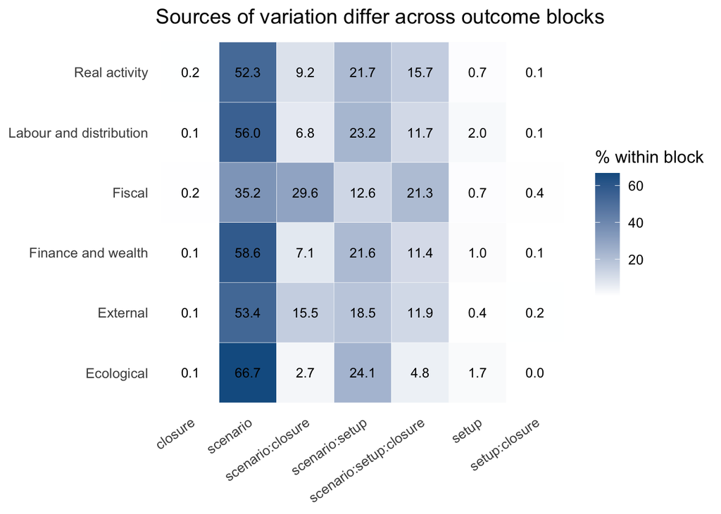

Ecological variation is predominantly between scenarios (66.7%), with an additional 24.1% scenario × setup component. Fiscal outcomes have a smaller scenario main component (35.2%) and large scenario × closure (29.6%) and three-way (21.3%) components. **Interpretation:** clustering all outcomes together combines a relatively scenario-driven ecological response with more configuration-dependent fiscal responses. The arm configurations include different baselines and aggregation; these ANOVA shares describe the grid and do not identify isolated causal parameter effects.

## Why ANOVA does not discover or validate the clusters

A clustering algorithm chooses groups to make their response vectors internally similar and externally different. Testing those fitted labels with ANOVA on the same response coordinates repeats the criterion used to create the groups. Small within-group variation is expected by construction. A resulting significance statement would not independently validate the groups or identify their number.

Descriptive between-group variation for the original seven pooled groups and two scenario-profile groups. Group labels were fitted on the same coordinates; these fractions are not independent validation.

| cohort | weighted_between_ss | weighted_total_ss | fraction_between |
| --- | --- | --- | --- |
| pooled | 417.8133 | 570 | 0.7330 |
| profiles | 21.7665 | 66 | 0.3298 |

Independent confirmation would need a genuinely different evaluation target or design: for example, groups fixed before examining a new parameter grid, assessed against additional outcomes. Repeating identical deterministic simulations would not provide random replication.

## The cluster hierarchy and the dependence on the cut

Ward D2 clustering starts with individual observations and repeatedly merges the pair of groups producing the smallest increase in within-group squared Euclidean variation. The result is a hierarchy, represented as a tree. A cut selects a number of groups from that hierarchy. Silhouette compares each observation’s average distance to its own group with its average distance to the nearest competing group; larger mean values favour clearer separation. Singletons receive zero. These criteria measure response geometry, not economic mechanisms.

Ward D2 cut sensitivity. ‘All nonsaturated cuts’ means k = 2…95 pooled and 2…11 for scenario profiles. The minimum-size criterion is a new exploratory constraint, not the original selection rule.

| cohort | criterion | k | silhouette | singletons | smallest_cluster | negative_silhouettes |
| --- | --- | --- | --- | --- | --- | --- |
| pooled | k 2 to 8 | 7 | 0.4831 | 2 | 1 | 4 |
| pooled | k 2 to 20 | 17 | 0.5637 | 3 | 1 | 2 |
| pooled | all nonsaturated cuts | 28 | 0.6473 | 9 | 1 | 0 |
| pooled | minimum group size 2 | 4 | 0.4441 | 0 | 4 | 4 |
| profiles | k 2 to 8 | 2 | 0.3870 | 0 | 2 | 1 |
| profiles | k 2 to 20 | 2 | 0.3870 | 0 | 2 | 1 |
| profiles | all nonsaturated cuts | 2 | 0.3870 | 0 | 2 | 1 |
| profiles | minimum group size 2 | 2 | 0.3870 | 0 | 2 | 1 |

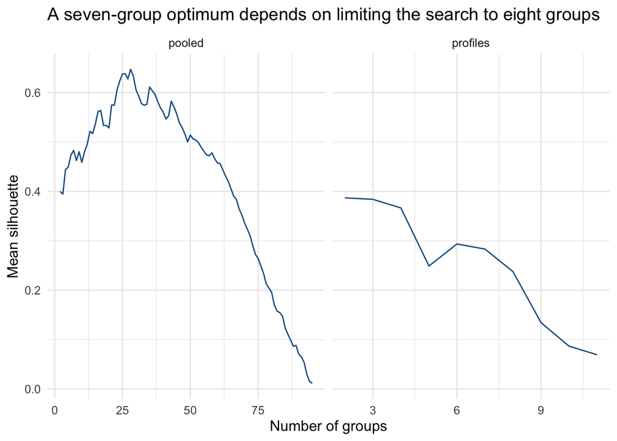

**Correction in interpretation:** the original report accurately said that seven maximised silhouette over k = 2…8. That restricted optimum should not be interpreted as an unconstrained optimum. Expanding to k = 2…20 selects 17 groups (silhouette 0.5637), and all nonsaturated cuts select 28 (0.6473). The latter has nine singleton groups. Related gold/fiat/quasi-float responses can form tight small groups, so a geometric criterion can reward increasing fragmentation of configurations within the same scenario. No additional simulation has generated 28 new intervention mechanisms.

If every group must contain at least two observations, the pooled optimum is k = 4 (silhouette 0.4441). That is a transparent alternative reporting rule, not evidence for the manuscript’s four named regimes. The membership below shows what those four groups actually contain.

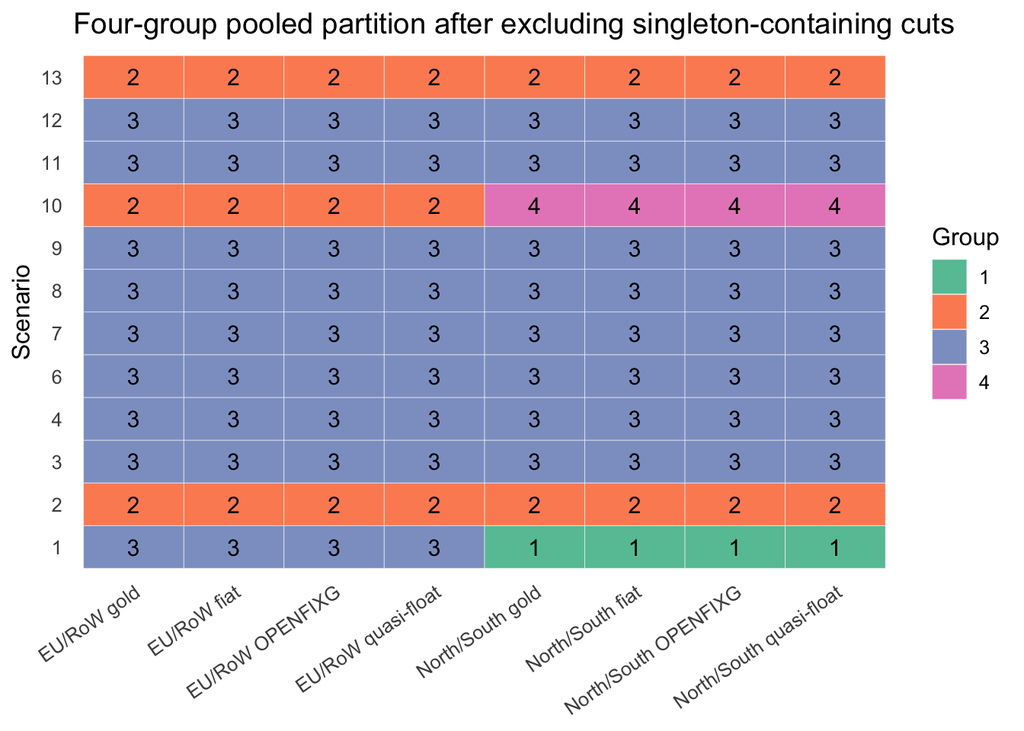

For comparison, the original seven groups contain 3, 20, 65, 3, 1, 1 and 3 observations. Three North/South food responses form one group; energy scenarios 2 and 13 plus EU/RoW metal-production scenario 10 form a 20-observation group; 65 other responses form a broad mixed group; three North/South metal responses form another group; the two North/South OPENFIXG food/metal responses are singletons; and three EU/RoW OPENFIXG food/plastics responses form the last group. This partition mixes intervention, aggregation, closure and response magnitude.

The scenario-profile hierarchy is easier to inspect because it has only twelve objects. The figure reconstructs its tree directly from the tracked response CSV, without relying on the untracked fit RDS.

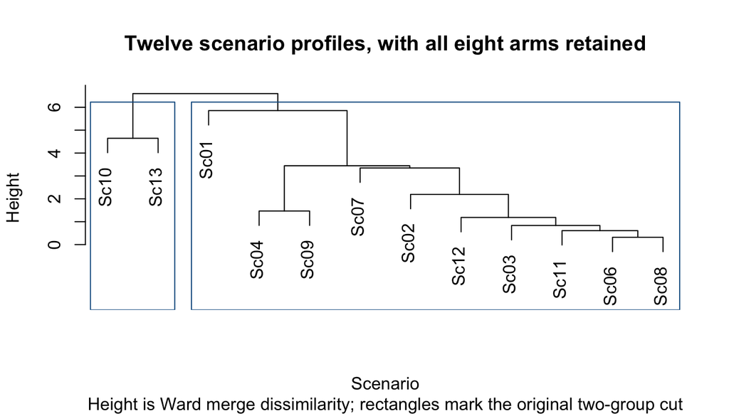

Ward selects `{10,13}` versus the other ten even when all profile cuts k = 2…11 are examined. Its two-group silhouette is 0.3870, only slightly larger than the three-group value 0.3840. Earlier average and complete linkage instead isolate scenario 1, with adjusted Rand agreement −0.1096 against Ward. Adjusted Rand agreement compares which pairs two partitions place together, adjusting for chance agreement; here it is a partition comparison, not a hypothesis test.

## What remains stable when measurement choices change?

We ran **200 reproducible variable-selection perturbations for each representation**. Within each outcome block, each draw keeps the ceiling of 80% of its variables, chosen without replacement. Both regions and all eight arms of a retained variable stay together. Every draw recomputes standardisation and block weights, then selects the best silhouette cut over k = 2…8. The selection range deliberately matches the original analysis. These are stress tests of measurement choices, not a row bootstrap, population confidence interval, or claim that the 200 draws are 200 new observations.

Preferred k over 200 variable-selection perturbations per representation; the denominator is 200 constructed measurement choices, not interventions.

| cohort | selected_k | Freq | share_percent |
| --- | --- | --- | --- |
| pooled | 2 | 90 | 45.0 |
| profiles | 2 | 136 | 68.0 |
| pooled | 3 | 13 | 6.5 |
| profiles | 3 | 64 | 32.0 |
| pooled | 7 | 82 | 41.0 |
| pooled | 8 | 15 | 7.5 |

Adjusted Rand agreement with the original cut: ‘selected’ allows k to change within 2…8; ‘fixed’ holds k at seven pooled or two profiles.

| cohort | ari_selected | ari_fixed |
| --- | --- | --- |
| pooled | 0.1612734 | 0.3155563 |
| profiles | -0.1095890 | 1.0000000 |

For scenario profiles, 136 of 200 draws select two groups and 64 select three. Scenarios 10 and 13 are grouped together in **all 200 draws**, and their highest co-grouping frequency with any outside scenario is 7%. Co-grouping frequency counts how often a pair occupies the same group, regardless of arbitrary group numbers. It is conditional on Ward linkage, these feature perturbations and the stated cut range. It does not overturn the earlier linkage sensitivity.

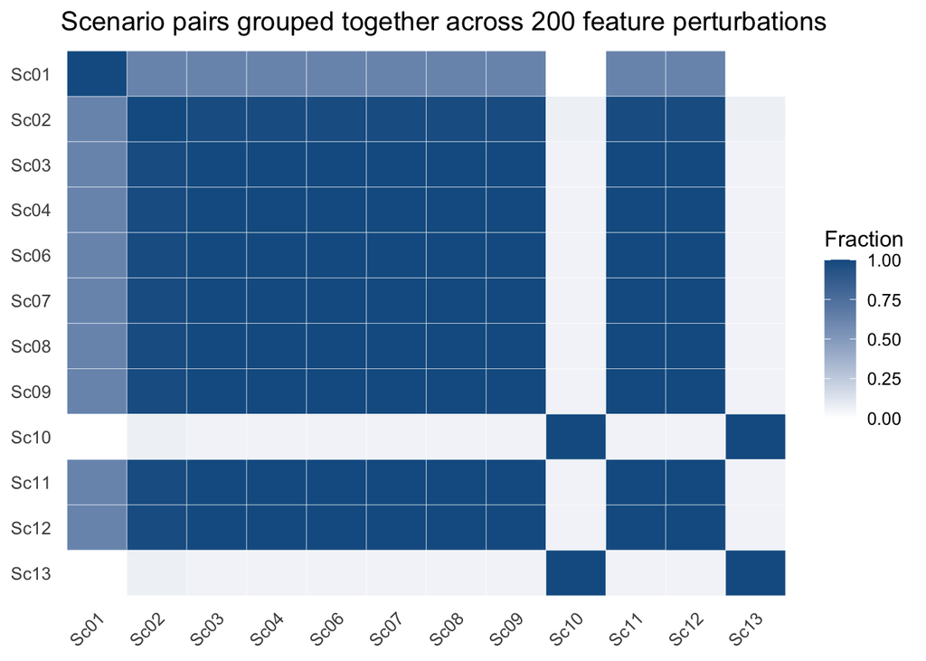

Within-group and strongest outside-pair co-grouping frequencies under reselected k. A singleton has no within-group pair, so its within frequency is unavailable.

| cohort | cluster | n | within_selected_coassociation | max_outside_selected_coassociation |
| --- | --- | --- | --- | --- |
| pooled | 1 | 3 | 1.0000 | 0.515 |
| pooled | 2 | 20 | 1.0000 | 0.515 |
| pooled | 3 | 65 | 0.9769 | 0.535 |
| pooled | 4 | 3 | 1.0000 | 0.515 |
| pooled | 5 | 1 | NA | 0.515 |
| pooled | 6 | 1 | NA | 0.515 |
| pooled | 7 | 3 | 1.0000 | 0.535 |
| profiles | 1 | 10 | 0.9223 | 0.070 |
| profiles | 2 | 2 | 1.0000 | 0.070 |

## Does a no-cluster reference resolve the count?

A supplementary gap calculation compares within-group dispersion with dispersion in simulated, unclustered reference clouds. Here the reference is uniform within the coordinate ranges after principal-component rotation, using squared Euclidean distances, Ward linkage, 200 reference draws and fixed random seeds. Principal components rotate the weighted response coordinates into orthogonal axes ordered by their variance. The reference describes geometric spread, not a model of feasible stock-flow-consistent economies. The [R gap-statistic documentation](https://stat.ethz.ch/R-manual/R-devel/RHOME/library/cluster/html/clusGap.html) defines that reference and the alternative selection rules.

The Tibshirani one-standard-error rule chooses the first k whose gap is no worse than the next k within its simulation variability. Unlike silhouette, it can choose k = 1. It chooses **one group** for both pooled observations and scenario profiles. The package’s first-local-maximum rule also chooses one. Simply taking the largest gap chooses the **upper search boundary**: k = 20 pooled and k = 10 profiles. That disagreement reinforces the lack of a count established by several criteria; it is not proof that responses are identical or that there is literally one transmission mechanism. The uniform reference changes the cross-coordinate and repeated-arm structure of the observed grid.

Gap choices, conditional on the PCA-box reference; k = 1…20 pooled and 1…10 profiles.

| cohort | method | selected_k |
| --- | --- | --- |
| pooled | Tibs2001SEmax | 1 |
| pooled | firstSEmax | 1 |
| pooled | globalmax | 20 |
| profiles | Tibs2001SEmax | 1 |
| profiles | firstSEmax | 1 |
| profiles | globalmax | 10 |

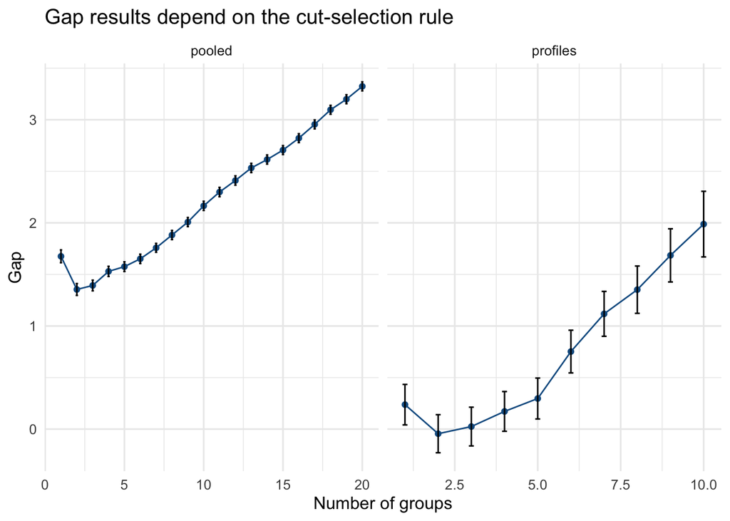

## What the report establishes

**Measured structure:** scenario effects dominate the weighted response variation, but almost half of that variation lies in interactions. Fiscal outcomes are especially closure-dependent. The original pooled seven groups are one resolution of a hierarchical response structure; their preferred count changes with the candidate range and feature choices. The `{10,13}` profile similarity is strong under Ward and variable omission, while the competing isolation of scenario 1 under other linkages remains unresolved.

**Interpretation:** a useful empirical description is a scenario-driven response hierarchy with substantial configuration-dependent deviations. A universal list of economic regimes would require a stronger connection between stable response groups and specified mechanisms. ANOVA helps identify where the differences occur; it does not discover the groups or solve the count problem. The minimum-size four-group cut is available as a transparent descriptive simplification, but is not a confirmation of the existing four-name taxonomy.

All conclusions are conditional on period 90, these 37 measures, their baseline denominators, the selected weighting and distance, and the completed revised grid. They do not generalise to omitted construction scenarios or OPENFLEX. OPENFLEX diagnosis is a separate trajectory exercise. Scenario 6 remains exactly as simulated, and its near-inert response does not resolve its intended replacement-capital interpretation. The four maintainer decisions—scenario 6, `par_xr`, the short North/South fiat reserve and the enterprise premium with Ξ—remain open.

## Reproduction and evidence files

Run from the repository root:

```bash
Rscript R/scenarios/transmission_cluster_structure.R
quarto render qmd/reports/2026-10-02-transmission-variance-and-cluster-structure.qmd --to html --output-dir "$PWD/output/html/reports"
```

The original evidence is `R/scenarios/cluster_transmission_grid.R` and `output/calibration/transmission_clusters_20261002/`, including `inputs.csv`, `responses.csv`, original memberships, silhouette schedules and linkage/block/arm sensitivity. The earlier standalone account is `qmd/reports/2026-10-02-pooled-transmission-clusters.qmd`.

The new computation writes `output/calibration/transmission_structure_20261002/`: `anova_total.csv`, `anova_blocks.csv` and `anova_features.csv` contain the factorial decomposition; `extended_silhouettes.csv`, `cut_choices.csv`, `cut_memberships.csv` and `memberships.csv` preserve the partitions; `cluster_feature_separation.csv` contains descriptive between-group shares; `pca_variance.csv` and `pca_scores.csv` preserve the principal-component geometry; `feature_perturbations.csv`, `perturbation_variables.csv`, `coassociation.csv` and `cluster_stability.csv` preserve every feature draw and its pairwise results; `gap_schedule.csv` and `gap_choices.csv` preserve the reference comparison. `provenance.json` records input/script hashes, seed, repeat count, package versions and the limitations of each calculation. No accepted simulation was rerun and no earlier fit cache was overwritten.